# OpenCVアプリの基礎

画像処理アプリの流れは以下の通り

1. 画像の入力
2. 画像の加工
3. 画像の保存

ここでは，MacBookAirのカメラから動画（一定間隔の画像）取得し，画像を加工表示したり保存したりするプログラムを学ぶ

# サンプルプログラム

lecture06_camera_image_capture.py

```python
#!/usr/bin/env python
# -*- coding: utf-8 -*-
import numpy as np
import cv2

class MyVideoCapture():
    DELAY=100 # 100 msecのディレイ

    def __init__(self):
        # PCによってはカメラID=0ではなく1を指定するとうまくいく
        self.cap = cv2.VideoCapture(0)
        self.cap.set(cv2.CAP_PROP_FRAME_WIDTH, 640)
        self.cap.set(cv2.CAP_PROP_FRAME_HEIGHT, 480)

    def run(self):
        while(True):
            # カメラ画像を１枚キャプチャする
            ret, frame = self.cap.read()

            # リターンコードが0でなければ終了
            if not ret:
                break

            # キャプチャしたカメラ画像を加工
            img = np.copy(frame) # 加工するともとの画像が保存できないのでコピーを生成
            # 画像の中心を示すターゲットマークを描画
            rows, cols, channels = img.shape
            img = cv2.circle(img, (int(cols/2), int(rows/2)), 30, (0, 0, 255), 3)
            img = cv2.circle(img, (int(cols/2), int(rows/2)), 60, (0, 0, 255), 3)
            img = cv2.line(img, (int(cols/2), int(rows/2) - 80), (int(cols/2), int(rows/2) + 80), (0, 0, 255), 3)
            img = cv2.line(img, (int(cols/2) - 80, int(rows/2)), (int(cols/2) + 80, int(rows/2)), (0, 0, 255), 3)

            # 左右反転（顔を撮るときは左右反転しておくとよい, 0: 上下反転, 1: 左右反転, -1: 左右上下反転）
            img = cv2.flip(img, flipCode=1)

            # 加工した画像を表示
            cv2.imshow('frame', img)

            # 次の画像を処理するまでに時間間隔（msec）を空ける
            # キーボードのqが押されたら終了
            if cv2.waitKey(self.DELAY) & 0xFF == ord('q'):
                self.captuered_img = frame
                break

    def get_img(self) -> cv2.Mat:
        """キャプチャ画像を取得
        """
        return self.captuered_img

    def write_img(self):
        """キャプチャ画像をファイルに保存
        """
        cv2.imwrite('camera_capture.png', self.captuered_img)

    def __del__(self):
        # 終了処理
        self.cap.release()
        cv2.destroyAllWindows()

if __name__ == "__main__":
    app = MyVideoCapture()
    app.run()
    app.write_img()
```

表示例（ターゲットマークが表示される）

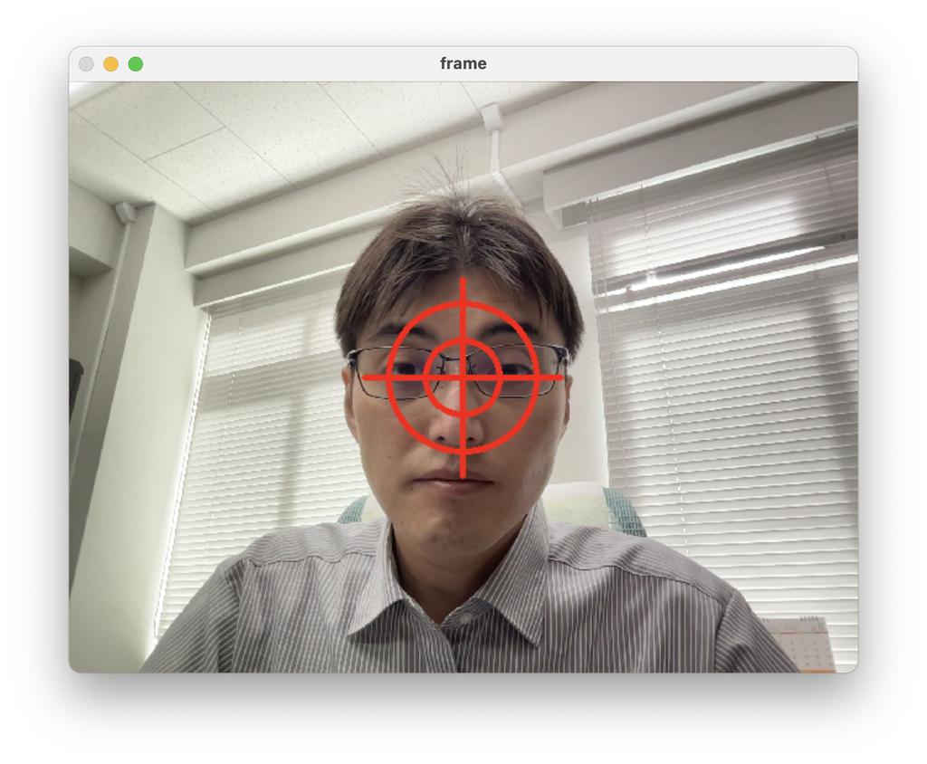

保存された画像の例（ターゲットマークは保存されない）

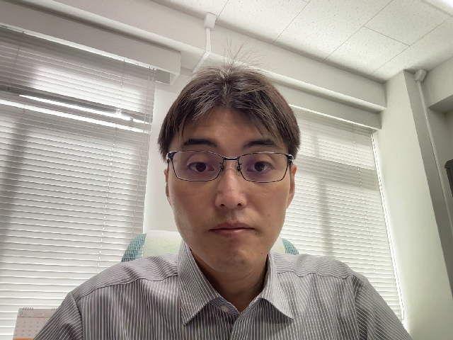

# 解説

OpenCVはカメラでキャプチャした画像（もちろん編集中の画像も）を表示することができる

表示画像と保存画像を分けるには，numpyモジュール機能のcopy関数を利用する（でないと参照渡しになってしまう）

ユーザーからの入力はキーボードによるものとしたがマウスの位置を指定して図形を描画するようなアプリも作成できるので挑戦してみてほしい（cv2.setMouseCallbackやcv2.EVENT_MOUSEMOVEなどで調べてみる）

# まとめ

pythonで画像を扱うためのモジュールOpenCVを紹介した

OpenCVでは画像ファイルを開く以外にカメラセンサーから画像を取得することができる

カメラから画像を取得することができれば物体認識といった最近のAI画像処理を気軽に試すことができる